# Computing the DFC/HP and manipulating the functions returned objects

Hassan-Roland Nasser and Marie Schneider

2024-12-19

```r
library(digiRhythm)
data <- digiRhythm::df691b_1
data <- resample_dgm(data, 15)
data <- remove_activity_outliers(data)
activity <- names(data)[3]
head(activity)
```

```
#> [1] "Steps"
```

# Degree of Functional Coupling (DFC) and Harmonic Power (HP)

The degree of functional coupling and the harmonic power could be computed using the dfc function as shown below.

The DFC algorithm is a bit complicated. It’s, therefore, needed that we clarify few points about some computing considerations and also about the arguments of the function itself:

- The recommended sampling period is between 15 and 30 min.
- The DFC and HP are computed each X days. We call X the rolling window. For example, if the rolling window is 7 days, the first DFC/HP value is computed for the subset between day 1 and day 7, and the second DFC/HP value is computed for the subset between day 2 and day 8, and so on. If the data contains 8 days of data, then we will only have two DFC and HP values. The recommended rolling window is 7 days, however the user can choose a rolling window not less than two days and not more that the number of days in the dataset -1.
- As the computation of DFC/HP are mainly based on the power of the 24-hours harmonics (24/1 is the first harmonic, 24/2 is the second harmonic, 24/3 is the third harmonic, and so on), the user can choose up till which harmonic to consider. The default value is 12. It’s important to note that the lowest harmonic period should be twice bigger than the sampling period. For example, if your data is sampled at 15 minutes, then the lowest harmonic period should be 30 minutes. This is because the Nyquist frequency is half the sampling frequency. Consequently, the harmonic cutoff parameter should be set to not more than 48 (because 24 hours * 60 min / 48 = 30 min = 2 * 15 min of sampling period).

The user does not need to worry about looping over days or extracting the Lomb Scargle periodogram for every X (rolling window) days and then compile the results to obtain the degree of functional coupling. This is done in loop inside the dfc function. However, there is also a function call lomb_scargle_periodogram where the user can investigate the activity a little bit deeper. We preview the lomb_scargle_periodogram function and its output, then we go to the dfc function.

```
#> v Correct time format: First column has a POSIXct Format
#> v Number of days good for DFC: 8 days >= 2 days
#> v Correct numeric format - Column 2 ==> Steps
#> The data is digiRhythm friendly
```

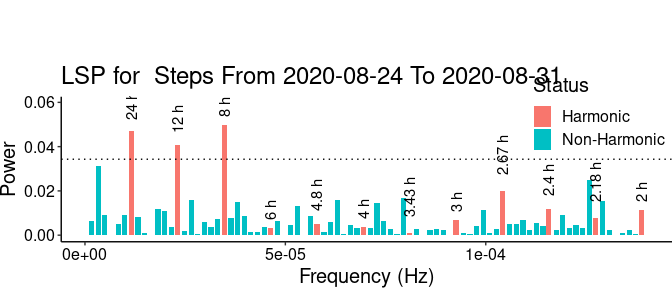

```r
df <- data[1:672, c("datetime", activity)]
my_lsp <- lomb_scargle_periodogram(df, alpha = 0.01, plot = TRUE)
```

Now, to the DFC. The below plot shows the DFC and HP in the same graph. Both variables are percentages.

[output not shown]

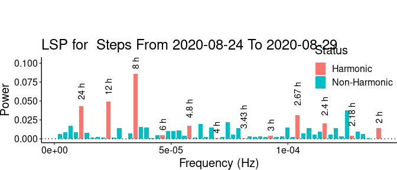

```
#> v Correct time format: First column has a POSIXct Format
#> v Number of days good for DFC: 6 days >= 2 days
#> v Correct numeric format - Column 2 ==> Steps
#> The data is digiRhythm friendly
```

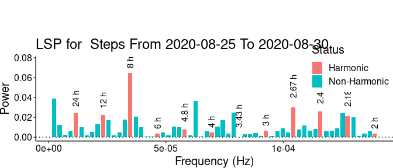

```
#> v Correct time format: First column has a POSIXct Format
#> v Number of days good for DFC: 6 days >= 2 days
#> v Correct numeric format - Column 2 ==> Steps
#> The data is digiRhythm friendly
```

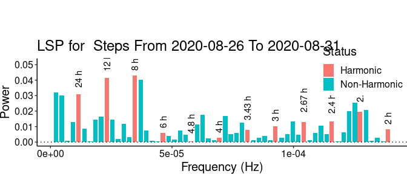

```
#> v Correct time format: First column has a POSIXct Format
#> v Number of days good for DFC: 6 days >= 2 days
#> v Correct numeric format - Column 2 ==> Steps
#> The data is digiRhythm friendly
```

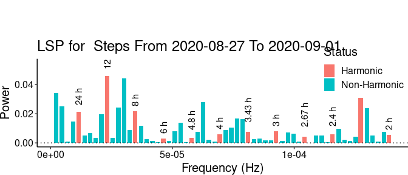

```
#> v Correct time format: First column has a POSIXct Format
#> v Number of days good for DFC: 6 days >= 2 days
#> v Correct numeric format - Column 2 ==> Steps
#> The data is digiRhythm friendly
```

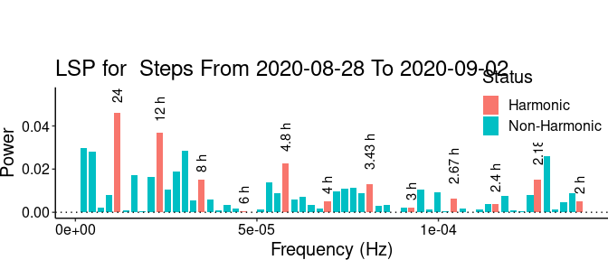

```
#> v Correct time format: First column has a POSIXct Format
#> v Number of days good for DFC: 6 days >= 2 days
#> v Correct numeric format - Column 2 ==> Steps
#> The data is digiRhythm friendly
```

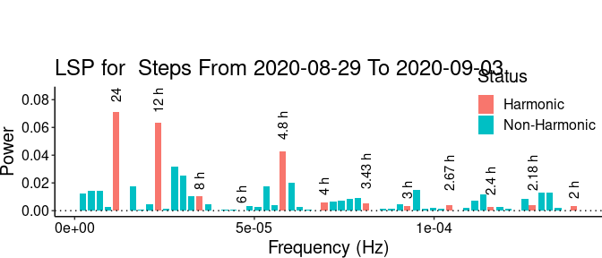

```
#> v Correct time format: First column has a POSIXct Format
#> v Number of days good for DFC: 6 days >= 2 days
#> v Correct numeric format - Column 2 ==> Steps
#> The data is digiRhythm friendly
```

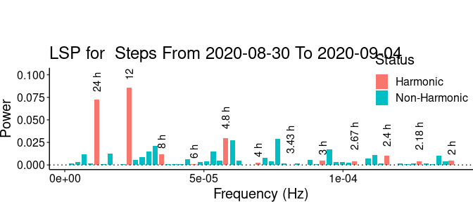

```
#> v Correct time format: First column has a POSIXct Format
#> v Number of days good for DFC: 6 days >= 2 days
#> v Correct numeric format - Column 2 ==> Steps
#> The data is digiRhythm friendly
```

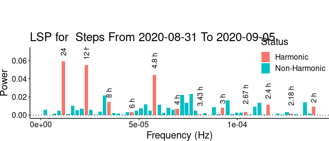

```
#> v Correct time format: First column has a POSIXct Format
#> v Number of days good for DFC: 6 days >= 2 days
#> v Correct numeric format - Column 2 ==> Steps
#> The data is digiRhythm friendly
```

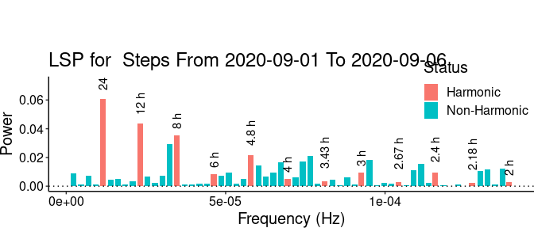

```
#> v Correct time format: First column has a POSIXct Format
#> v Number of days good for DFC: 6 days >= 2 days
#> v Correct numeric format - Column 2 ==> Steps
#> The data is digiRhythm friendly
```

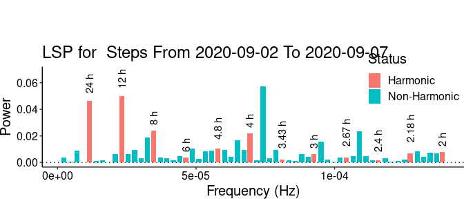

```
#> v Correct time format: First column has a POSIXct Format
#> v Number of days good for DFC: 6 days >= 2 days
#> v Correct numeric format - Column 2 ==> Steps
#> The data is digiRhythm friendly
```

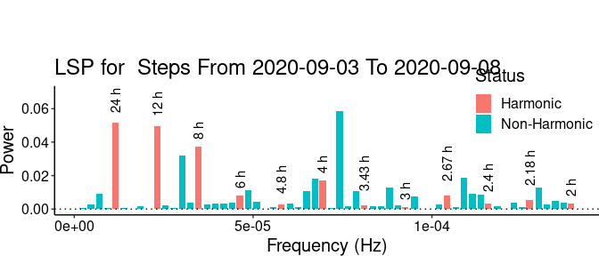

```
#> v Correct time format: First column has a POSIXct Format
#> v Number of days good for DFC: 6 days >= 2 days
#> v Correct numeric format - Column 2 ==> Steps
#> The data is digiRhythm friendly
```

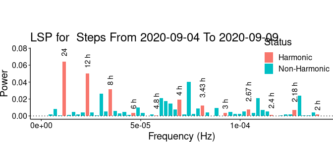

```
#> v Correct time format: First column has a POSIXct Format
#> v Number of days good for DFC: 6 days >= 2 days
#> v Correct numeric format - Column 2 ==> Steps
#> The data is digiRhythm friendly
```

[30 more figures not shown]

```r
my_dfc <- dfc(data, # The dataset
  activity = activity, # the name of the activity column
  sampling = 15, # the sampling frequency of my dataset is 15
  alpha = 0, 5, # significance level
  harm_cutoff = 12, # up till the harmonic 24/12 which is two hours
  plot = FALSE, verbose = FALSE
)
```

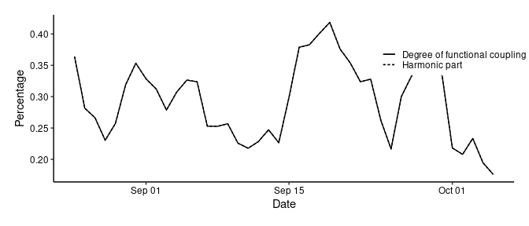

```r
# Setting plot to TRUE will visualize all the LSP plots (like the one above)
# during each sliding window. Rather used for deeper investigation and
# debugging.
print(my_dfc)
```

# Accessing output data and changing the plots using DigiRhythm

The DFC function returns a object of type ggplot:

```r
class(my_dfc)
```

```
#> [1] "gg"     "ggplot"
```

As shown, the class is gg or ggplot. This allows the user to: - Access the data of DFC or HP directly from the returned object. - Add aesthetics layer to the plot as needed.

To access the data, user has to use the *data* component of the DFC object. We illustrate this in the below code:

```r
head(my_dfc$data)
```

```
#>         from         to       dfc        hp
#> 1 2020-08-25 2020-08-29 0.3639380 0.3639380
#> 2 2020-08-26 2020-08-30 0.2815203 0.2815203
#> 3 2020-08-27 2020-08-31 0.2664486 0.2664486
#> 4 2020-08-28 2020-09-01 0.2304376 0.2304376
#> 5 2020-08-29 2020-09-02 0.2571856 0.2571856
#> 6 2020-08-30 2020-09-03 0.3189433 0.3189433
```

Users can also change the aesthetics of the plot directly if they wish. This is possible by adding a ggplot layer to the returned DFC object. For instance, this is the original plot returned by the DFC:

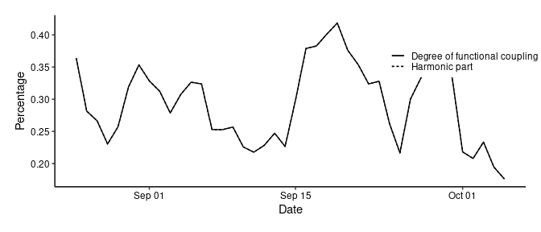

```r
print(my_dfc)
```

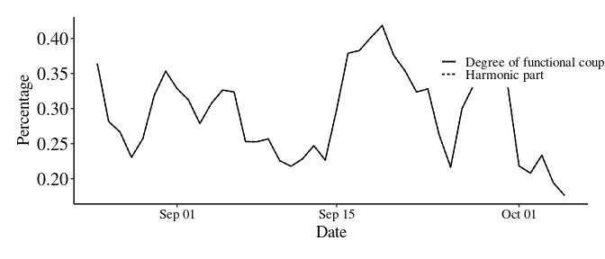

```r
library(ggplot2)
new_plot <- my_dfc +
  theme(
    text = element_text(family = "Times", size = 14),
    axis.text.y = element_text(size = 15, colour = "black")
  )
print(new_plot)
```